# Decision Trees

INSOFE Lab Activity on Decision Trees

23 July 2017

# C5.0 Trees

**NOTE** Before starting this assignment please remember to clear your environment, you can do that by running the following code chunk

```r
rm(list = ls(all=TRUE))
```

## Goal

- The goal of this activity is to predict wether a patient has liver disease or not based on various patient related attributes

## Agenda

- Get the data
- Data Pre-processing
- build a model
- predictions
- Communication

## Reading & Understanding the Data

### Read the Data

Make sure the dataset is located in your current working directory, or else you can change your working directory using the “setwd()” function.

```r
getwd()
```

```
## [1] "C:/Users/G Amit/Desktop/assignment"
```

```r
patient_data<-read.csv("ilpd_data.csv")
```

### Understand the data

- Use the str(), summary(), head() and tail() functions to get the dimensions and types of attributes in the dataset
- The dataset has 582 observations and 11 variables
- **The variable descriptions are given below:**

1 - age : Age of the patient

2 - gender : Gender of the patient

3 - TB : Total Bilirubin content

4 - DB : Direct Bilirubin content

5 - alk_phos : Alkaline Phosphotase content

6 - alamine : Alamine Aminotransferase content

7 - aspartate : Aspartate Aminotransferase content

8 - TP : Total Protiens content

9 - albumin : Albumin content

10 - A/G : Ratio of Albumin and Globulin

11 - Disease : Whether the patient has liver disease or not

```r
str(patient_data)
```

```
## 'data.frame':    582 obs. of  11 variables:
##  $ age      : int  62 62 58 72 46 26 29 17 55 57 ...
##  $ gender   : Factor w/ 2 levels "Female","Male": 2 2 2 2 2 1 1 2 2 2 ...
##  $ TB       : num  10.9 7.3 1 3.9 1.8 0.9 0.9 0.9 0.7 0.6 ...
##  $ DB       : num  5.5 4.1 0.4 2 0.7 0.2 0.3 0.3 0.2 0.1 ...
##  $ alk_phos : int  699 490 182 195 208 154 202 202 290 210 ...
##  $ alamine  : int  64 60 14 27 19 16 14 22 53 51 ...
##  $ aspartate: int  100 68 20 59 14 12 11 19 58 59 ...
##  $ TP       : num  7.5 7 6.8 7.3 7.6 7 6.7 7.4 6.8 5.9 ...
##  $ albumin  : num  3.2 3.3 3.4 2.4 4.4 3.5 3.6 4.1 3.4 2.7 ...
##  $ A.G      : num  0.74 0.89 1 0.4 1.3 1 1.1 1.2 1 0.8 ...
##  $ disease  : Factor w/ 2 levels "no","yes": 2 2 2 2 2 2 2 1 2 2 ...
```

```r
summary(patient_data)
```

```
##       age           gender          TB               DB
##  Min.   : 4.00   Female:141   Min.   : 0.400   Min.   : 0.100
##  1st Qu.:33.00   Male  :441   1st Qu.: 0.800   1st Qu.: 0.200
##  Median :45.00                Median : 1.000   Median : 0.300
##  Mean   :44.71                Mean   : 3.303   Mean   : 1.488
##  3rd Qu.:57.75                3rd Qu.: 2.600   3rd Qu.: 1.300
##  Max.   :90.00                Max.   :75.000   Max.   :19.700
##
##     alk_phos         alamine          aspartate            TP
##  Min.   :  63.0   Min.   :  10.00   Min.   :  10.0   Min.   :2.700
##  1st Qu.: 175.2   1st Qu.:  23.00   1st Qu.:  25.0   1st Qu.:5.800
##  Median : 208.0   Median :  35.00   Median :  42.0   Median :6.600
##  Mean   : 290.8   Mean   :  80.82   Mean   : 110.1   Mean   :6.483
##  3rd Qu.: 298.0   3rd Qu.:  60.75   3rd Qu.:  87.0   3rd Qu.:7.200
##  Max.   :2110.0   Max.   :2000.00   Max.   :4929.0   Max.   :9.600
##
##     albumin           A.G         disease
##  Min.   :0.900   Min.   :0.3000   no :167
##  1st Qu.:2.600   1st Qu.:0.7000   yes:415
##  Median :3.100   Median :0.9400
##  Mean   :3.142   Mean   :0.9471
##  3rd Qu.:3.800   3rd Qu.:1.1000
##  Max.   :5.500   Max.   :2.8000
##                  NA's   :4
```

```r
head(patient_data,n=6)
```

```
##   age gender   TB  DB alk_phos alamine aspartate  TP albumin  A.G disease
## 1  62   Male 10.9 5.5      699      64       100 7.5     3.2 0.74     yes
## 2  62   Male  7.3 4.1      490      60        68 7.0     3.3 0.89     yes
## 3  58   Male  1.0 0.4      182      14        20 6.8     3.4 1.00     yes
## 4  72   Male  3.9 2.0      195      27        59 7.3     2.4 0.40     yes
## 5  46   Male  1.8 0.7      208      19        14 7.6     4.4 1.30     yes
## 6  26 Female  0.9 0.2      154      16        12 7.0     3.5 1.00     yes
```

```r
tail(patient_data,n=6)
```

```
##     age gender   TB  DB alk_phos alamine aspartate  TP albumin  A.G
## 577  32   Male 12.7 8.4      190      28        47 5.4     2.6 0.90
## 578  60   Male  0.5 0.1      500      20        34 5.9     1.6 0.37
## 579  40   Male  0.6 0.1       98      35        31 6.0     3.2 1.10
## 580  52   Male  0.8 0.2      245      48        49 6.4     3.2 1.00
## 581  31   Male  1.3 0.5      184      29        32 6.8     3.4 1.00
## 582  38   Male  1.0 0.3      216      21        24 7.3     4.4 1.50
##     disease
## 577     yes
## 578      no
## 579     yes
## 580     yes
## 581     yes
## 582      no
```

## Data Pre-processing

### Verify Data Integrity

- Verify if the dataset has missing values

```r
sum(is.na(patient_data))
```

```
## [1] 4
```

- Verify the data types assigned to the variables in the dataset

```r
str(patient_data)
```

```
## 'data.frame':    582 obs. of  11 variables:
##  $ age      : int  62 62 58 72 46 26 29 17 55 57 ...
##  $ gender   : Factor w/ 2 levels "Female","Male": 2 2 2 2 2 1 1 2 2 2 ...
##  $ TB       : num  10.9 7.3 1 3.9 1.8 0.9 0.9 0.9 0.7 0.6 ...
##  $ DB       : num  5.5 4.1 0.4 2 0.7 0.2 0.3 0.3 0.2 0.1 ...
##  $ alk_phos : int  699 490 182 195 208 154 202 202 290 210 ...
##  $ alamine  : int  64 60 14 27 19 16 14 22 53 51 ...
##  $ aspartate: int  100 68 20 59 14 12 11 19 58 59 ...
##  $ TP       : num  7.5 7 6.8 7.3 7.6 7 6.7 7.4 6.8 5.9 ...
##  $ albumin  : num  3.2 3.3 3.4 2.4 4.4 3.5 3.6 4.1 3.4 2.7 ...
##  $ A.G      : num  0.74 0.89 1 0.4 1.3 1 1.1 1.2 1 0.8 ...
##  $ disease  : Factor w/ 2 levels "no","yes": 2 2 2 2 2 2 2 1 2 2 ...
```

### Split the Data into train and test sets

- Use stratified sampling to split the data into train/test sets (70/30)
- Use the createDataPartition() function from the caret package to do stratified sampling

```r
require(lattice)
```

```r
require(ggplot2)
library(caret)
set.seed(022)
train_row<-createDataPartition(patient_data$disease,p=0.7,list = F)
patient_train<-patient_data[train_row, ]
patient_test<-patient_data[-train_row, ]
```

### Impute the missing values

- Impute missing values using knnImputation() function in both the train and test datasets

```r
require(grid)
library(DMwR)
patient_train<-knnImputation(data = patient_train,k=5)
sum(is.na(patient_train))
```

```
## [1] 0
```

```r
patient_test<-knnImputation(data=patient_test,k=5)
sum(is.na(patient_test))
```

```
## [1] 0
```

## build a Decision Tree

### Model the tree

- Use Quinlan’s C5.0 decision tree algorithm implementation from the C50 package to build your decision tree

```r
library(C50)
c5_dec_tree<-C5.0(disease ~. , patient_train)
```

- build a rules based tree

```r
c5_rule<-C5.0(disease ~., patient_train,rules=T)
```

### Variable Importance in trees

- Find the importance of each variable in the dataset

```r
C5imp(c5_dec_tree,metric = "usage")
```

```
##           Overall
## TB         100.00
## alamine     78.19
## gender      66.18
## alk_phos    12.01
## age         11.52
## DB          10.54
## aspartate    0.00
## TP           0.00
## albumin      0.00
## A.G          0.00
```

### Rules from trees

- Understand the summary of the returned c5.0 rules based on the decision tree model

```r
summary(c5_rule)
```

```
##
## Call:
## C5.0.formula(formula = disease ~ ., data = patient_train, rules = T)
##
##
## C5.0 [Release 2.07 GPL Edition]      Sun Aug 06 12:06:39 2017
## -------------------------------
##
## Class specified by attribute `outcome'
##
## Read 408 cases (11 attributes) from undefined.data
##
## Rules:
##
## Rule 1: (5, lift 3.0)
##  age <= 25
##  gender = Female
##  TB > 0.7
##  TB <= 2.7
##  ->  class no  [0.857]
##
## Rule 2: (27/10, lift 2.2)
##  gender = Female
##  TB <= 0.7
##  alamine <= 67
##  ->  class no  [0.621]
##
## Rule 3: (80/3, lift 1.3)
##  alk_phos > 183
##  alamine > 67
##  ->  class yes  [0.951]
##
## Rule 4: (284/61, lift 1.1)
##  age > 25
##  TB > 0.7
##  ->  class yes  [0.783]
##
## Rule 5: (307/79, lift 1.0)
##  gender = Male
##  ->  class yes  [0.741]
```

[output cut: 14 more lines]

```
##    ----  ----
##      22    95    (a): class no
##      10   281    (b): class yes
##
##
##  Attribute usage:
##
##   83.09% gender
##   77.45% TB
##   70.83% age
##   26.23% alamine
##   19.61% alk_phos
##
##
## Time: 0.0 secs
```

### Plotting the tree

- Call the plot function on the tree object to visualize the tree

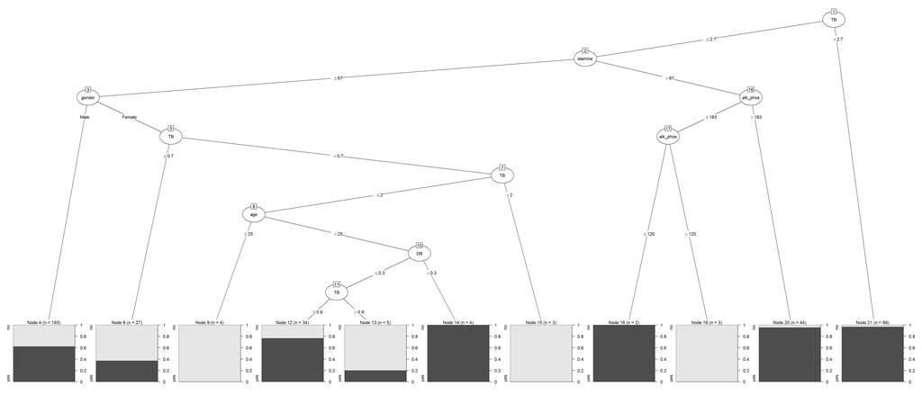

```r
plot(c5_dec_tree)
```

## Evaluating the model

### predictions on the test data

- Evaluate the decision tree using the standard error metrics on test data

```r
pred_tree<-predict(c5_dec_tree,patient_test)
```

- Report error metrics for classification on test data

```r
library(caret)

confusionMatrix(pred_tree,patient_test$disease)
```

```
## Confusion Matrix and Statistics
##
##           Reference
## Prediction  no yes
##        no    5  13
##        yes  45 111
##
##                Accuracy : 0.6667
##                  95% CI : (0.5914, 0.7362)
##     No Information Rate : 0.7126
##     P-Value [Acc > NIR] : 0.9212
##
##                   Kappa : -0.006
##  Mcnemar's Test P-Value : 4.691e-05
##
##             Sensitivity : 0.10000
##             Specificity : 0.89516
##          Pos Pred Value : 0.27778
##          Neg Pred Value : 0.71154
##              Prevalence : 0.28736
##          Detection Rate : 0.02874
##    Detection Prevalence : 0.10345
##       Balanced Accuracy : 0.49758
##
##        'Positive' Class : no
##
```

# CART Trees

**NOTE** Before starting this assignment please remember to clear your environment, you can do that by running the following code chunk

```r
rm(list = ls(all= T))
```

- The classification and regression trees use gini index in place of the gain ratio (based on information gain) used by the ID3 based algorithms, such as c4.5 and c5.0

## Goal

- The goal of this activity is to predict the heating load of a residential building, if the building parameters are given
- Hence, in the future architects would be able to build more energy efficient buildings as they can optimize the building parameters to reduce the heating load

## Agenda

- Get the data
- Data Pre-processing
- build a model
- predictions
- Communication

## Reading & Understanding the Data

### Read the Data

- Make sure the dataset is located in your current working directory, or else you can change your working directory using the “setwd()” function.

```r
getwd()
```

```
## [1] "C:/Users/G Amit/Desktop/assignment"
```

```r
build<-read.csv("building_energy.csv")
```

### Understand the data

- Use the str(), summary(), head() and tail() functions to get the dimensions and types of attributes in the dataset
- The dataset has 768 observations and 9 variables

```r
str(build)
```

```
## 'data.frame':    768 obs. of  9 variables:
##  $ relative_compactness     : num  0.98 0.98 0.98 0.98 0.9 0.9 0.9 0.9 0.86 0.86 ...
##  $ surface_area             : num  514 514 514 514 564 ...
##  $ wall_area                : num  294 294 294 294 318 ...
##  $ roof_area                : num  110 110 110 110 122 ...
##  $ overall_height           : num  7 7 7 7 7 7 7 7 7 7 ...
##  $ orientation              : int  2 3 4 5 2 3 4 5 2 3 ...
##  $ glazing_area             : num  0 0 0 0 0 0 0 0 0 0 ...
##  $ glazing_area_distribution: int  0 0 0 0 0 0 0 0 0 0 ...
##  $ heating_load             : num  15.6 15.6 15.6 15.6 20.8 ...
```

```r
summary(build)
```

```
##  relative_compactness  surface_area     wall_area       roof_area
##  Min.   :0.6200       Min.   :514.5   Min.   :245.0   Min.   :110.2
##  1st Qu.:0.6825       1st Qu.:606.4   1st Qu.:294.0   1st Qu.:140.9
##  Median :0.7500       Median :673.8   Median :318.5   Median :183.8
##  Mean   :0.7642       Mean   :671.7   Mean   :318.5   Mean   :176.6
##  3rd Qu.:0.8300       3rd Qu.:741.1   3rd Qu.:343.0   3rd Qu.:220.5
##  Max.   :0.9800       Max.   :808.5   Max.   :416.5   Max.   :220.5
##  overall_height  orientation    glazing_area    glazing_area_distribution
##  Min.   :3.50   Min.   :2.00   Min.   :0.0000   Min.   :0.000
##  1st Qu.:3.50   1st Qu.:2.75   1st Qu.:0.1000   1st Qu.:1.750
##  Median :5.25   Median :3.50   Median :0.2500   Median :3.000
##  Mean   :5.25   Mean   :3.50   Mean   :0.2344   Mean   :2.812
##  3rd Qu.:7.00   3rd Qu.:4.25   3rd Qu.:0.4000   3rd Qu.:4.000
##  Max.   :7.00   Max.   :5.00   Max.   :0.4000   Max.   :5.000
##   heating_load
##  Min.   : 6.01
##  1st Qu.:12.99
##  Median :18.95
##  Mean   :22.31
##  3rd Qu.:31.67
##  Max.   :43.10
```

```r
head(build,n=5)
```

```
##   relative_compactness surface_area wall_area roof_area overall_height
## 1                 0.98        514.5     294.0    110.25              7
## 2                 0.98        514.5     294.0    110.25              7
## 3                 0.98        514.5     294.0    110.25              7
## 4                 0.98        514.5     294.0    110.25              7
## 5                 0.90        563.5     318.5    122.50              7
##   orientation glazing_area glazing_area_distribution heating_load
## 1           2            0                         0        15.55
## 2           3            0                         0        15.55
## 3           4            0                         0        15.55
## 4           5            0                         0        15.55
## 5           2            0                         0        20.84
```

```r
tail(build,n=5)
```

```
##     relative_compactness surface_area wall_area roof_area overall_height
## 764                 0.64        784.0     343.0     220.5            3.5
## 765                 0.62        808.5     367.5     220.5            3.5
## 766                 0.62        808.5     367.5     220.5            3.5
## 767                 0.62        808.5     367.5     220.5            3.5
## 768                 0.62        808.5     367.5     220.5            3.5
##     orientation glazing_area glazing_area_distribution heating_load
## 764           5          0.4                         5        17.88
## 765           2          0.4                         5        16.54
## 766           3          0.4                         5        16.44
## 767           4          0.4                         5        16.48
## 768           5          0.4                         5        16.64
```

- The variable names are self explanatory, for further information visit http://www.sciencedirect.com/science/article/pii/S037877881200151X

## Data Pre-processing

### Verify Data Integrity

- Verify if the dataset has missing values

```r
sum(is.na(build))
```

```
## [1] 0
```

- Verify the data types assigned to the variables in the dataset

```r
str(build)
```

```
## 'data.frame':    768 obs. of  9 variables:
##  $ relative_compactness     : num  0.98 0.98 0.98 0.98 0.9 0.9 0.9 0.9 0.86 0.86 ...
##  $ surface_area             : num  514 514 514 514 564 ...
##  $ wall_area                : num  294 294 294 294 318 ...
##  $ roof_area                : num  110 110 110 110 122 ...
##  $ overall_height           : num  7 7 7 7 7 7 7 7 7 7 ...
##  $ orientation              : int  2 3 4 5 2 3 4 5 2 3 ...
##  $ glazing_area             : num  0 0 0 0 0 0 0 0 0 0 ...
##  $ glazing_area_distribution: int  0 0 0 0 0 0 0 0 0 0 ...
##  $ heating_load             : num  15.6 15.6 15.6 15.6 20.8 ...
```

### Split the Data

- Split the data into train/test sets (70/30)

```r
library(caret)

set.seed(123)

train_r<-createDataPartition(build$heating_load,p=0.7,list = F)
build_train<-build[train_r, ]
build_test<-build[-train_r, ]
```

## build a Regression Tree

### Model the tree

- Use the rpart package to build a cart tree to predict the heating load

```r
library(rpart)

reg_tree<-rpart(heating_load ~., build_train)
printcp(reg_tree)
```

```
##
## Regression tree:
## rpart(formula = heating_load ~ ., data = build_train)
##
## Variables actually used in tree construction:
## [1] glazing_area         relative_compactness wall_area
##
## Root node error: 56735/540 = 105.06
##
## n= 540
##
##         CP nsplit rel error   xerror      xstd
## 1 0.806306      0  1.000000 1.003848 0.0377514
## 2 0.078815      1  0.193694 0.195782 0.0125905
## 3 0.019753      2  0.114879 0.115774 0.0086037
## 4 0.019101      3  0.095126 0.103002 0.0082473
## 5 0.015296      4  0.076025 0.081666 0.0055670
## 6 0.010000      5  0.060729 0.066990 0.0047403
```

### Tree Explicability

- Print the variable importance

```r
reg_tree$variable.importance
```

```
##      relative_compactness              surface_area
##                50217.1630                50217.1630
##            overall_height                 roof_area
##                45745.6091                45745.6091
##                 wall_area              glazing_area
##                17987.3021                 3206.3147
##               orientation glazing_area_distribution
##                  866.3941                  646.7762
```

- Plot the regression tree

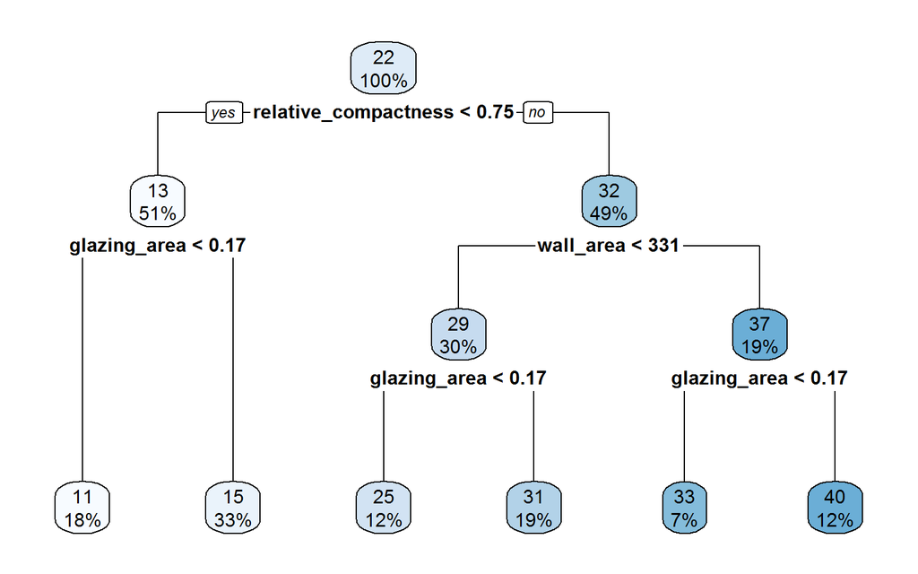

```r
library(rpart.plot)
rpart.plot(reg_tree)
```

## Evaluation on Test Data

- Report error metrics on the test data

```r
pred_trees<-predict(reg_tree,build_test)
```

```r
library(DMwR)

regr.eval(build_test$heating_load,pred_trees)
```

```
##       mae       mse      rmse      mape
## 2.1873776 8.6679035 2.9441304 0.1137696
```